# Airline_Passenger_Satifaction_project

[figure not shown]

### ❓ Problem Statment

# 📊🔧 Data Environment Setup

```python
# Import essential libraries for data manipulation and visualization
import pandas as pd                                         # for working with data in tabular form (DataFrames)
import numpy as np                                          # for numerical computations and array operations

import matplotlib.pyplot as plt                             # for creating plots and charts
import seaborn as sns                                       # for advanced visualizations with better styling
from colorama import Fore                                   # for printing colored text in the console (e.g., errors, alerts)

from sklearn.model_selection import train_test_split        # Importing the train_test_split function to split the dataset into training and testing sets

from sklearn.preprocessing import LabelEncoder              # Import class to convert categorical labels to numeric codes

from sklearn.model_selection import cross_val_score         # Import cross_val_score from sklearn.model_selection to perform cross-validation on the model


from sklearn.linear_model import LogisticRegression         # Logistic Regression: a simple and interpretable linear classification model
from sklearn.tree import DecisionTreeClassifier             # Decision Tree: a non-linear model that splits data into branches for classification
from sklearn.ensemble import RandomForestClassifier         # Random Forest: an ensemble of decision trees to reduce overfitting
from sklearn.ensemble import GradientBoostingClassifier     # Gradient Boosting: builds trees sequentially to correct errors from previous ones
from sklearn.svm import SVC                                 # Support Vector Classifier: effective in high-dimensional spaces, aims to find the optimal decision boundary
from sklearn.neighbors import KNeighborsClassifier          # K-Nearest Neighbors: classifies based on the majority label of nearest data points
from xgboost import XGBClassifier                           # XGBoost: a powerful and efficient gradient boosting algorithm optimized for speed and performance

import time                                                 # Importing the time library to calc the time to train models
from sklearn.metrics import classification_report           # Importing the classification_report to generate a detailed performance report (precision, recall, and F1-score).
from sklearn.metrics import accuracy_score                  # Importing accuracy_score to calculate the accuracy of the classification model
from sklearn.metrics import confusion_matrix                # Used to compute the confusion matrix for actual vs predicted labels
from sklearn.metrics import ConfusionMatrixDisplay          # Used to visualize the confusion matrix as a plot

from sklearn.model_selection import GridSearchCV            # Tool for performing exhaustive search over specified hyperparameter values using cross-validation

from sklearn.pipeline import Pipeline                       # Used to create modeling pipelines
from sklearn.preprocessing import StandardScaler            # Used for feature scaling (standardization)

import joblib                                               # Import the joblib library to save and load the trained model efficiently

# Set visualization style to dark grid for better readability
sns.set_style("darkgrid")

# Configure pandas display options to show full data without truncation
pd.set_option("display.max_columns", None)                  # Show all columns in outputs
pd.set_option("display.max_colwidth", None)                 # Show full content of each column (no '...')

# Suppress FutureWarning messages to keep the output clean
import warnings
warnings.simplefilter(action='ignore', category=FutureWarning)

np.random.seed(42)                                          # Set random seed for reproducibility (ensures same random results every time)
```

# 📥🔍 Loading and Discovering the Training Dataset

- loading the data

```python
# Load the dataset from a CSV file into a DataFrame
df = pd.read_csv('Airline_Passenger_Satifaction_Data.csv')
print('Loading is Done')
```

```
Loading is Done
```

```
C:\Users\Ahmed Adel\AppData\Local\Temp\ipykernel_2132\3579890249.py:2: DtypeWarning: Columns (13) have mixed types. Specify dtype option on import or set low_memory=False.
  df = pd.read_csv('Airline_Passenger_Satifaction_Data.csv')
```

- Showing some details about our data

```python
# Returns a tuple with the number of rows and columns in the DataFrame (rows, columns)
df.shape
```

```
(103988, 25)
```

```python
# Shows the first 5 rows of the DataFrame to get a quick overview of the data
df.head()
```

|  | Unnamed: 0 | id | Gender | Customer Type | Age | Type of Travel | Class | Flight Distance | Inflight wifi service | Departure/Arrival time convenient | Ease of Online booking | Gate location | Food and drink | Online boarding | Seat comfort | Inflight entertainment | On-board service | Leg room service | Baggage handling | Checkin service | Inflight service | Cleanliness | Departure Delay in Minutes | Arrival Delay in Minutes | satisfaction |
| --- | --- | --- | --- | --- | --- | --- | --- | --- | --- | --- | --- | --- | --- | --- | --- | --- | --- | --- | --- | --- | --- | --- | --- | --- | --- |
| 0 | 0 | 70172 | Male | Loyal Customer | 13.0 | Personal Travel | Eco Plus | 460.0 | 3.0 | 4 | 3.0 | 1 | 5.0 | 3 | 5.0 | 5.0 | 4.0 | 3.0 | 4.0 | 4.0 | 5.0 | 5.0 | 25.0 | 18.0 | neutral or dissatisfied |
| 1 | 1 | 5047 | NaN | disloyal Customer | 25.0 | Business travel | Business | 235.0 | 3.0 | 2 | 3.0 | 3 | 1.0 | 3 | 1.0 | 1.0 | 1.0 | 5.0 | 3.0 | 1.0 | 4.0 | 1.0 | 1.0 | 6.0 | neutral or dissatisfied |
| 2 | 2 | 110028 | Female | Loyal Customer | 26.0 | Business travel | Business | 1142.0 | 2.0 | 2 | 2.0 | 2 | 5.0 | 5 | 5.0 | 5.0 | 4.0 | 3.0 | 4.0 | 4.0 | 4.0 | 5.0 | 0.0 | 0.0 | satisfied |
| 3 | 3 | 24026 | Female | Loyal Customer | 25.0 | Business travel | Business | 562.0 | 2.0 | 5 | 5.0 | 5 | 2.0 | 2 | 2.0 | 2.0 | 2.0 | 5.0 | 3.0 | 1.0 | 4.0 | 2.0 | 11.0 | 9.0 | neutral or dissatisfied |
| 4 | 4 | 119299 | Male | Loyal Customer | 61.0 | Business travel | Business | 214.0 | 3.0 | 3 | 3.0 | 3 | 4.0 | 5 | 5.0 | 3.0 | 3.0 | 4.0 | 4.0 | 3.0 | 3.0 | 3.0 | 0.0 | 0.0 | satisfied |

```python
# Displays summary info about the DataFrame: columns, non-null values, and data types
df.info()
```

```
<class 'pandas.core.frame.DataFrame'>
RangeIndex: 103988 entries, 0 to 103987
Data columns (total 25 columns):
 #   Column                             Non-Null Count   Dtype
---  ------                             --------------   -----
 0   Unnamed: 0                         103988 non-null  int64
 1   id                                 103988 non-null  int64
 2   Gender                             103980 non-null  object
 3   Customer Type                      103983 non-null  object
 4   Age                                103982 non-null  float64
 5   Type of Travel                     103985 non-null  object
 6   Class                              103986 non-null  object
 7   Flight Distance                    103986 non-null  float64
 8   Inflight wifi service              103987 non-null  float64
 9   Departure/Arrival time convenient  103988 non-null  int64
```

[output cut: 17 more lines]

- Exploring unknown values in data

```python
# Shows the number of missing (NaN) values in each column of the DataFrame
df.isna().sum()
```

```
Unnamed: 0                             0
id                                     0
Gender                                 8
Customer Type                          5
Age                                    6
Type of Travel                         3
Class                                  2
Flight Distance                        2
Inflight wifi service                  1
Departure/Arrival time convenient      0
Ease of Online booking                 2
Gate location                          0
Food and drink                         1
Online boarding                        1
Seat comfort                           2
Inflight entertainment                 4
On-board service                       1
Leg room service                       3
Baggage handling                       1
Checkin service                        1
Inflight service                       2
Cleanliness                            1
Departure Delay in Minutes             1
Arrival Delay in Minutes             311
satisfaction                           1
dtype: int64
```

```python
# Show all rows that contain at least one NaN value
df[df.isna().any(axis=1)].head(10)
```

|  | Unnamed: 0 | id | Gender | Customer Type | Age | Type of Travel | Class | Flight Distance | Inflight wifi service | Departure/Arrival time convenient | Ease of Online booking | Gate location | Food and drink | Online boarding | Seat comfort | Inflight entertainment | On-board service | Leg room service | Baggage handling | Checkin service | Inflight service | Cleanliness | Departure Delay in Minutes | Arrival Delay in Minutes | satisfaction |
| --- | --- | --- | --- | --- | --- | --- | --- | --- | --- | --- | --- | --- | --- | --- | --- | --- | --- | --- | --- | --- | --- | --- | --- | --- | --- |
| 1 | 1 | 5047 | NaN | disloyal Customer | 25.0 | Business travel | Business | 235.0 | 3.0 | 2 | 3.0 | 3 | 1.0 | 3 | 1.0 | 1.0 | 1.0 | 5.0 | 3.0 | 1.0 | 4.0 | 1.0 | 1.0 | 6.0 | neutral or dissatisfied |
| 7 | 7 | 96462 | Female | NaN | 52.0 | Business travel | Business | 2035.0 | 4.0 | 3 | 4.0 | 4 | 5.0 | 5 | 5.0 | 5.0 | 5.0 | 5.0 | 5.0 | 4.0 | 5.0 | 4.0 | 4.0 | 0.0 | satisfied |
| 10 | 10 | 34991 | NaN | disloyal Customer | 24.0 | Business travel | Eco | 1182.0 | 4.0 | 5 | 5.0 | 4 | 2.0 | 5 | 2.0 | 2.0 | 3.0 | 3.0 | 5.0 | 3.0 | 5.0 | 2.0 | 0.0 | 0.0 | neutral or dissatisfied |
| 21 | 21 | 22434 | NaN | Loyal Customer | 17.0 | Personal Travel | Eco | 208.0 | 3.0 | 1 | 3.0 | 3 | 5.0 | 3 | 5.0 | 5.0 | 2.0 | 5.0 | 3.0 | 3.0 | 4.0 | 5.0 | 0.0 | 0.0 | neutral or dissatisfied |
| 32 | 32 | 70594 | Female | Loyal Customer | 35.0 | Business travel | Business | 2611.0 | NaN | 5 | 4.0 | 4 | 4.0 | 4 | 4.0 | 3.0 | 3.0 | 4.0 | 5.0 | 4.0 | 3.0 | 4.0 | 109.0 | 120.0 | satisfied |
| 39 | 39 | 64685 | Male | disloyal Customer | 41.0 | NaN | Business | 354.0 | 1.0 | 1 | 1.0 | 2 | 1.0 | 1 | 1.0 | 1.0 | 3.0 | 3.0 | 4.0 | 4.0 | 4.0 | 1.0 | 0.0 | 0.0 | neutral or dissatisfied |
| 48 | 48 | 53164 | Male | NaN | 54.0 | Business travel | Business | 612.0 | 3.0 | 3 | 3.0 | 3 | 5.0 | 2 | 3.0 | 5.0 | 5.0 | 5.0 | 5.0 | 4.0 | 5.0 | 3.0 | 8.0 | 0.0 | satisfied |
| 53 | 53 | 54886 | Male | Loyal Customer | 35.0 | Personal Travel | Eco | 775.0 | 2.0 | 3 | 2.0 | 4 | NaN | 2 | 4.0 | 4.0 | 4.0 | 4.0 | 3.0 | 4.0 | 1.0 | 4.0 | 1.0 | 0.0 | neutral or dissatisfied |
| 65 | 65 | 78610 | Male | Loyal Customer | 25.0 | Business travel | Business | 1426.0 | 3.0 | 3 | 3.0 | 3 | 4.0 | NaN | NaN | NaN | 5.0 | 4.0 | 4.0 | 4.0 | 4.0 | 4.0 | 4.0 | 0.0 | satisfied |
| 76 | 76 | 85018 | Male | Loyal Customer | 52.0 | Business travel | Business | 1190.0 | 2.0 | 4 | NaN | 4 | 1.0 | 4 | 3.0 | 2.0 | 2.0 | 2.0 | 2.0 | 1.0 | 2.0 | 4.0 | 0.0 | 6.0 | neutral or dissatisfied |

- Exploring duplicated rows in data

```python
# Checks if there are any duplicated rows in the DataFrame and returns True or False
print(df.duplicated().any())

# Count duplicated rows
print(df.duplicated().sum())
```

```
True
66
```

- Exploring illogical values in data

```python
# Display columns that contain at least one negative value (numeric only)
negative_columns = df.select_dtypes(include=[np.number]).columns[(df.select_dtypes(include=[np.number]) < 0).any()]
print("Columns with negative values:", list(negative_columns))
```

```
Columns with negative values: ['Age']
```

- Display summary statistics for all object columns

```python
# Display summary statistics for categorical (object type) columns
df.describe(include="O")
```

|  | Gender | Customer Type | Type of Travel | Class | Online boarding | satisfaction |
| --- | --- | --- | --- | --- | --- | --- |
| count | 103980 | 103983 | 103985 | 103986 | 103987 | 103987 |
| unique | 2 | 2 | 2 | 3 | 13 | 2 |
| top | Female | Loyal Customer | Business travel | Business | 4 | neutral or dissatisfied |
| freq | 52764 | 84986 | 71715 | 49706 | 20956 | 58928 |

### ✅ After using these functions we noticed many things:

- Data loaded successfully.
- Number of Rows is: 103988.
- Number of columns is: 25.
- There are null values in 21 columns (359 NaN value in data).
- There is 66 complete duplicates.
- There is a column with negative values [Age].
- Unnamed:0 and id columns wouldn't be useful for our project.
- There is a problem with the data type in the 'online boarding' column (it is supposed to be numeric).

# 📈🧹 Data preparation and cleaning

At this stage we will get rid of unimportant columns and process all problems of the data.

- Delete unimportant columns

```python
# Delete columns with specific names
df = df.drop(columns=['Unnamed: 0', 'id'])

# To verify, print the column names after deletion
print(df.columns)
```

```
Index(['Gender', 'Customer Type', 'Age', 'Type of Travel', 'Class',
       'Flight Distance', 'Inflight wifi service',
       'Departure/Arrival time convenient', 'Ease of Online booking',
       'Gate location', 'Food and drink', 'Online boarding', 'Seat comfort',
       'Inflight entertainment', 'On-board service', 'Leg room service',
       'Baggage handling', 'Checkin service', 'Inflight service',
       'Cleanliness', 'Departure Delay in Minutes', 'Arrival Delay in Minutes',
       'satisfaction'],
      dtype='object')
```

- Remove duplicated rows

```python
# Remove duplicate rows
df = df.drop_duplicates()

# Verify the result by checking the shape
df.shape
```

```
(103922, 23)
```

- Process some unknown and fales values (Imputation)

Replace unknown, negative, or very large values with the average values in the 'Age' column.

```python
# Calculate the mean of valid ages (between 0 and 100)
valid_age_mean = df.loc[(df['Age'] > 0) & (df['Age'] < 100), 'Age'].mean()

# Replace ages less than 0 or greater than 100 with the valid mean
df.loc[(df['Age'] < 0) | (df['Age'] > 100), 'Age'] = valid_age_mean

# Replace NaN values with the mean
df['Age'].fillna(df['Age'].mean(), inplace=True)
```

- Drop rows of unknown values

Dropping unknown values is a good option because their number is small compared to the total data.

```python
# Drop rows that contain any NaN values
df = df.dropna()

# This will show the number of rows and columns after removal
print(df.shape)
```

```
(103581, 23)
```

- Ensuring that unknown values are deleted or processed

```python
# Shows the number of missing (NaN) values in each column of the DataFrame
df.isna().sum()
```

```
Gender                               0
Customer Type                        0
Age                                  0
Type of Travel                       0
Class                                0
Flight Distance                      0
Inflight wifi service                0
Departure/Arrival time convenient    0
Ease of Online booking               0
Gate location                        0
Food and drink                       0
Online boarding                      0
Seat comfort                         0
Inflight entertainment               0
On-board service                     0
Leg room service                     0
Baggage handling                     0
Checkin service                      0
Inflight service                     0
Cleanliness                          0
Departure Delay in Minutes           0
Arrival Delay in Minutes             0
satisfaction                         0
dtype: int64
```

> Great! Our Data without any NaN.
- discovering the type of each column

```python
# Loop through each column in the DataFrame
for col in df.columns:
    # Get the unique data types (after dropping NaNs)
    types = df[col].dropna().apply(type).unique()

    # If the column has only one type
    if len(types) == 1:
        # Check if it's numeric (int or float)
        if pd.api.types.is_numeric_dtype(df[col]):
            print(f"🔢 Numeric: {col}")
        else:
            print(f"🔤 Categorical: {col}")
    else:
        # Column contains mixed data types (e.g., int and str)
        print(f"⚠️ Mixed-type: {col} ({types})")
```

```
🔤 Categorical: Gender
🔤 Categorical: Customer Type
🔢 Numeric: Age
🔤 Categorical: Type of Travel
🔤 Categorical: Class
🔢 Numeric: Flight Distance
🔢 Numeric: Inflight wifi service
🔢 Numeric: Departure/Arrival time convenient
🔢 Numeric: Ease of Online booking
🔢 Numeric: Gate location
🔢 Numeric: Food and drink
⚠️ Mixed-type: Online boarding ([<class 'str'> <class 'int'>])
🔢 Numeric: Seat comfort
🔢 Numeric: Inflight entertainment
🔢 Numeric: On-board service
🔢 Numeric: Leg room service
🔢 Numeric: Baggage handling
🔢 Numeric: Checkin service
🔢 Numeric: Inflight service
🔢 Numeric: Cleanliness
🔢 Numeric: Departure Delay in Minutes
🔢 Numeric: Arrival Delay in Minutes
🔤 Categorical: satisfaction
```

> Oops! there is a problem with values in 'Online boarding' column. the values are mixed-type !!!

```python
# Print the frequency of each unique value in the 'Online boarding' column, including NaNs if any
print(df['Online boarding'].value_counts(dropna=False))

# Print the count of different data types present in the 'Online boarding' column
# This helps identify if the column contains mixed types (e.g., int and str), which can cause encoding issues
print(df['Online boarding'].apply(type).value_counts())
```

```
Online boarding
4    20872
3    15112
5    14214
2    11817
4     9792
1     7229
3     6628
5     6437
2     5633
1     3427
0     1675
0      745
Name: count, dtype: int64
Online boarding
<class 'int'>    70919
<class 'str'>    32662
Name: count, dtype: int64
```

> To solve this problem we neet to cast all values of column to integer data type

```python
# Convert all values in the 'Online boarding' column to integers
# Invalid parsing will be set as NaN (using 'errors="coerce"'), and we use 'Int64' to allow nullable integers
df['Online boarding'] = pd.to_numeric(df['Online boarding'], errors='coerce').astype('Int64')
```

```python
# Check if there are any missing (NaN) values in the 'Online boarding' column after conversion
df['Online boarding'].isna().any()
```

```
np.False_
```

- check dtype for each column

```python
# to know the number of Categorical columns
df.info()
```

```
<class 'pandas.core.frame.DataFrame'>
Index: 103581 entries, 0 to 103978
Data columns (total 23 columns):
 #   Column                             Non-Null Count   Dtype
---  ------                             --------------   -----
 0   Gender                             103581 non-null  object
 1   Customer Type                      103581 non-null  object
 2   Age                                103581 non-null  float64
 3   Type of Travel                     103581 non-null  object
 4   Class                              103581 non-null  object
 5   Flight Distance                    103581 non-null  float64
 6   Inflight wifi service              103581 non-null  float64
 7   Departure/Arrival time convenient  103581 non-null  int64
 8   Ease of Online booking             103581 non-null  float64
 9   Gate location                      103581 non-null  int64
 10  Food and drink                     103581 non-null  float64
 11  Online boarding                    103581 non-null  Int64
 12  Seat comfort                       103581 non-null  float64
 13  Inflight entertainment             103581 non-null  float64
 14  On-board service                   103581 non-null  float64
 15  Leg room service                   103581 non-null  float64
 16  Baggage handling                   103581 non-null  float64
 17  Checkin service                    103581 non-null  float64
 18  Inflight service                   103581 non-null  float64
 19  Cleanliness                        103581 non-null  float64
 20  Departure Delay in Minutes         103581 non-null  float64
 21  Arrival Delay in Minutes           103581 non-null  float64
 22  satisfaction                       103581 non-null  object
dtypes: Int64(1), float64(15), int64(2), object(5)
memory usage: 19.1+ MB
```

### ✅ Now, we can say that our data is almost ready

- Unnecessary columns were removed.
- Duplicate rows were removed.
- Some unknown values were processed and some were deleted.
- The data type of the columns was checked and the mixed-dtype issue was solved.

# 📶🧐 Data Visualization and Exploration (to Gain Insights)

```python
# the next 5 lines define the default font sizes
plt.rc('font', size=10)
plt.rc('axes', labelsize=14, titlesize=18)
plt.rc('legend', fontsize=14)
plt.rc('xtick', labelsize=12)
plt.rc('ytick', labelsize=12)
```

- Plot a Histogram for Each Column in the DataFrame

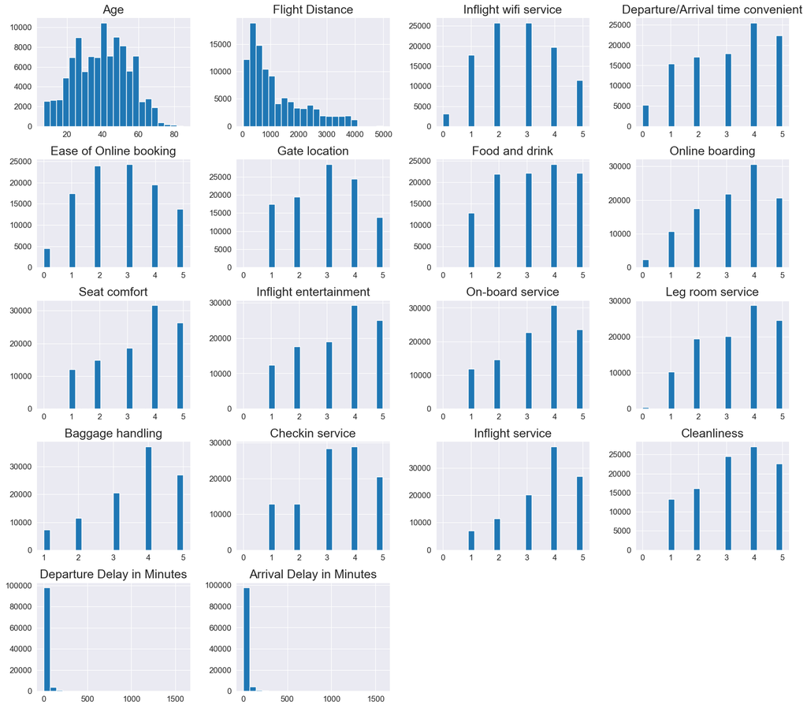

```python
# Generate histograms for all numerical columns in the DataFrame
df.hist(bins=22, figsize=(20, 18), grid = True)

# Show the histogram plot on the screen
plt.show()
```

- Age Distribution

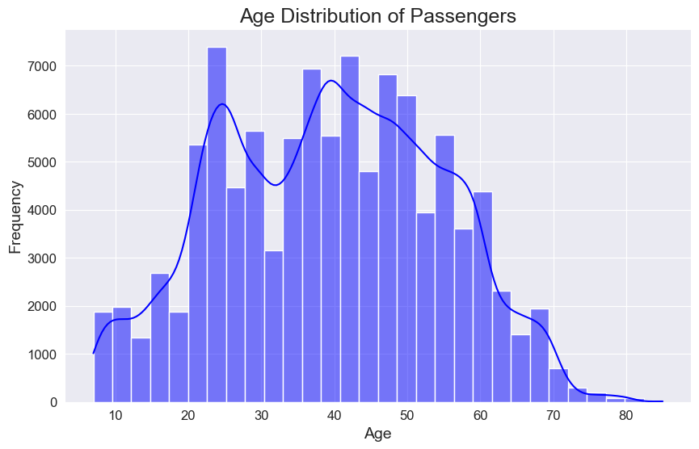

```python
# Focusing on Age, we'll analyze the age distribution using a histogram
plt.figure(figsize=(10, 6))
sns.histplot(df['Age'], kde=True, bins=30, color='blue')
plt.title('Age Distribution of Passengers')
plt.xlabel('Age')
plt.ylabel('Frequency')
plt.show()
# This code shows the distribution of ages in the dataset
```

- Satisfaction Distribution

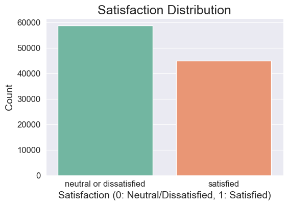

```python
# In this section, we will analyze the satisfaction distribution
plt.figure(figsize=(6, 4))
sns.countplot(data=df, x='satisfaction', palette="Set2")
plt.title('Satisfaction Distribution')
plt.xlabel('Satisfaction (0: Neutral/Dissatisfied, 1: Satisfied)')
plt.ylabel('Count')
plt.show()
# This plot shows the count of passengers who are satisfied (1) versus those who are neutral or dissatisfied (0).
```

- Departure Delay Distribution

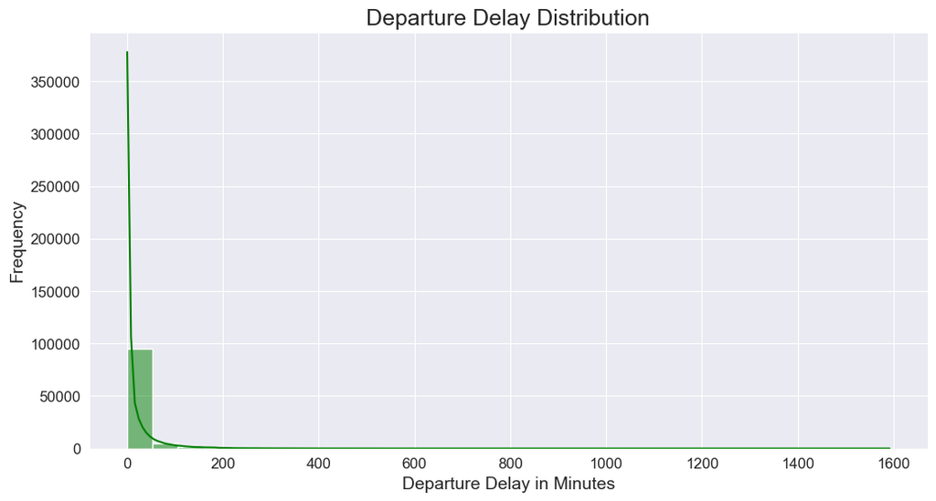

```python
# Here, we will visualize the departure delay distribution
plt.figure(figsize=(12, 6))
sns.histplot(df['Departure Delay in Minutes'], kde=True, bins=30, color='green')
plt.title('Departure Delay Distribution')
plt.xlabel('Departure Delay in Minutes')
plt.ylabel('Frequency')
plt.show()
# This analysis helps us understand the distribution of delays and how frequent they are.
```

- Correlation Heatmap (For Numeric Columns Only)

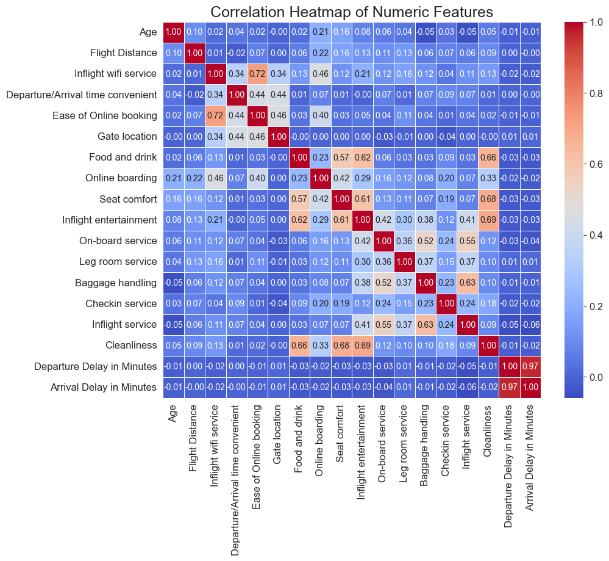

```python
# Select only numeric columns and compute correlation matrix
numeric_df = df.select_dtypes(include=[np.number])

# Now, calculate and plot the correlation heatmap
plt.figure(figsize=(10, 8))
sns.heatmap(numeric_df.corr(), annot=True, cmap="coolwarm", fmt=".2f", linewidths=0.5)
plt.title('Correlation Heatmap of Numeric Features')
plt.show()
# This version of the heatmap will only show correlations between numerical columns.
```

> The heatmap shows a strong correlation between 'Departure Delay in Minutes' & 'Arrival Delay in Minutes', let's go to dive into it to discover more about this

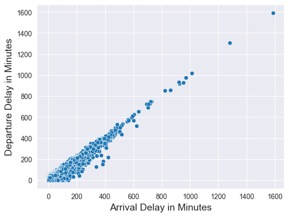

```python
# Set the font size for x and y axis tick labels to make the plot more readable
plt.rc('xtick', labelsize=10)
plt.rc('ytick', labelsize=10)
# Create a scatter plot to visualize the relationship between Arrival Delay and Departure Delay
sns.scatterplot(x='Arrival Delay in Minutes', y='Departure Delay in Minutes', data=df)
# Display the plot
plt.show()
```

> We can notice that Departure Delay is approximately equal to Arrival Delay. That tells us that the delay happens only before the start of the flight (not during the flight), it required feature engineering step

```python
# Calculate the flight delay by subtracting Departure Delay from Arrival Delay
df['Flight Delay'] = df['Arrival Delay in Minutes'] - df['Departure Delay in Minutes']

# Show the mean of the new column
print(df['Flight Delay'].mean())
```

```
0.43119877197555534
```

> Since the difference between 'Departure Delay' and 'Arrival Delay' is minimal (~0.43 minutes on average). we can safely remove one of them to avoid redundancy. We'll keep 'Departure Delay' and drop 'Arrival Delay'.

```python
# Drop 'Arrival Delay in Minutes' and the engineered 'Flight Delay' columns
# because they are highly correlated with 'Departure Delay in Minutes'
# and keeping all of them would cause multicollinearity in the model.
df.drop(columns=['Arrival Delay in Minutes', 'Flight Delay'], inplace=True)
```

- Missing Data Visualization

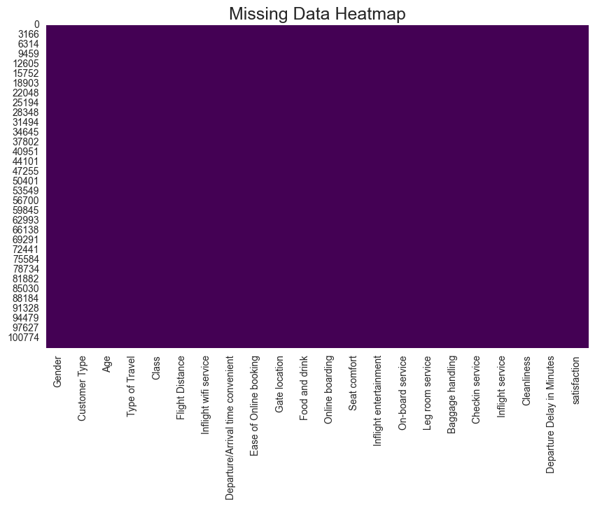

```python
# Here we will visualize the missing values in the dataset using a heatmap.
plt.figure(figsize=(10, 6))
sns.heatmap(df.isna(), cbar=False, cmap='viridis')
plt.title('Missing Data Heatmap')
plt.show()
# This heatmap highlights the missing (NaN) values in the dataset and allows us to check if any columns are missing values.
```

```python
# Displays summary info about the DataFrame: columns, non-null values, and data types
df.info()
```

```
<class 'pandas.core.frame.DataFrame'>
Index: 103581 entries, 0 to 103978
Data columns (total 22 columns):
 #   Column                             Non-Null Count   Dtype
---  ------                             --------------   -----
 0   Gender                             103581 non-null  object
 1   Customer Type                      103581 non-null  object
 2   Age                                103581 non-null  float64
 3   Type of Travel                     103581 non-null  object
 4   Class                              103581 non-null  object
 5   Flight Distance                    103581 non-null  float64
 6   Inflight wifi service              103581 non-null  float64
 7   Departure/Arrival time convenient  103581 non-null  int64
 8   Ease of Online booking             103581 non-null  float64
 9   Gate location                      103581 non-null  int64
 10  Food and drink                     103581 non-null  float64
 11  Online boarding                    103581 non-null  Int64
 12  Seat comfort                       103581 non-null  float64
 13  Inflight entertainment             103581 non-null  float64
 14  On-board service                   103581 non-null  float64
 15  Leg room service                   103581 non-null  float64
 16  Baggage handling                   103581 non-null  float64
 17  Checkin service                    103581 non-null  float64
 18  Inflight service                   103581 non-null  float64
 19  Cleanliness                        103581 non-null  float64
 20  Departure Delay in Minutes         103581 non-null  float64
 21  satisfaction                       103581 non-null  object
dtypes: Int64(1), float64(14), int64(2), object(5)
memory usage: 18.3+ MB
```

# 🪓📊 Data splitting (into train set and test set)

```python
# Drop the 'satisfaction' column from the DataFrame (X will be all the features except 'satisfaction')
X = df.drop("satisfaction", axis=1)

# Select the 'satisfaction' column as the target variable (y is the target we want to predict)
y = df["satisfaction"]

# Split the dataset into training and testing sets
# 80% of the data will be used for training, and 20% for testing
# The random_state ensures reproducibility (same split every time)
X_train, X_test, y_train, y_test = train_test_split(X, y, test_size=0.2, random_state=42)

# Show the number of samples in the training set (X_train), indicating how many training data points we have.
print(f"The number of samples in the training set is: {len(X_train)}")

# Show the number of samples in the test set (X_test), showing how many data points are in the test set.
print(f"The number of samples in the test set is: {len(X_test)}")
```

```
The number of samples in the training set is: 82864
The number of samples in the test set is: 20717
```

# 🔡🔢 Data encoding

- Encoding X (Features) with Mapping Print

```python
# Create a dictionary to store label encoders for each column
feature_encoders = {}

# Loop through object columns in X_train to fit and transform
for column in X_train.select_dtypes(include=['object']).columns:
    le = LabelEncoder()
    X_train[column] = le.fit_transform(X_train[column])
    X_test[column] = le.transform(X_test[column])
    feature_encoders[column] = le

    # Print mapping for this feature
    print(f"\nMapping for feature column: {column}")
    for i, class_ in enumerate(le.classes_):
        print(f"{class_} --> {i}")
```

```
Mapping for feature column: Gender
Female --> 0
Male --> 1

Mapping for feature column: Customer Type
Loyal Customer --> 0
disloyal Customer --> 1

Mapping for feature column: Type of Travel
Business travel --> 0
Personal Travel --> 1

Mapping for feature column: Class
Business --> 0
Eco --> 1
Eco Plus --> 2
```

- Encoding y (Target) with Mapping Print

```python
# Encode the target variable using LabelEncoder
target_encoder = LabelEncoder()
y_train = target_encoder.fit_transform(y_train)
y_test = target_encoder.transform(y_test)

# Print mapping for the target
print("\nMapping for target:")
for i, class_ in enumerate(target_encoder.classes_):
    print(f"{class_} --> {i}")
```

```
Mapping for target:
neutral or dissatisfied --> 0
satisfied --> 1
```

- Casting All Numeric Columns to Integer

```python
# Convert all values in the training and test sets (features and target) to integers
def cast_all_to_int(df):
    for column in df.select_dtypes(include=['float', 'int']).columns:
        df[column] = df[column].astype(int)
    return df

X_train = cast_all_to_int(X_train)                  # Cast all feature columns in X_train to integers
y_train = cast_all_to_int(pd.DataFrame(y_train))    # Cast the target column in y_train to integers
X_test = cast_all_to_int(X_test)                    # Cast all feature columns in X_test to integers
y_test = cast_all_to_int(pd.DataFrame(y_test))      # Cast the target column in y_test to integers

print(X_train.info())
print(y_train.info())
print(X_test.info())
print(y_test.info())
```

```
<class 'pandas.core.frame.DataFrame'>
Index: 82864 entries, 16048 to 15852
Data columns (total 21 columns):
 #   Column                             Non-Null Count  Dtype
---  ------                             --------------  -----
 0   Gender                             82864 non-null  int64
 1   Customer Type                      82864 non-null  int64
 2   Age                                82864 non-null  int64
 3   Type of Travel                     82864 non-null  int64
 4   Class                              82864 non-null  int64
 5   Flight Distance                    82864 non-null  int64
 6   Inflight wifi service              82864 non-null  int64
 7   Departure/Arrival time convenient  82864 non-null  int64
 8   Ease of Online booking             82864 non-null  int64
 9   Gate location                      82864 non-null  int64
 10  Food and drink                     82864 non-null  int64
 11  Online boarding                    82864 non-null  int64
 12  Seat comfort                       82864 non-null  int64
 13  Inflight entertainment             82864 non-null  int64
 14  On-board service                   82864 non-null  int64
 15  Leg room service                   82864 non-null  int64
 16  Baggage handling                   82864 non-null  int64
 17  Checkin service                    82864 non-null  int64
 18  Inflight service                   82864 non-null  int64
 19  Cleanliness                        82864 non-null  int64
 20  Departure Delay in Minutes         82864 non-null  int64
dtypes: int64(21)
memory usage: 13.9 MB
None
<class 'pandas.core.frame.DataFrame'>
RangeIndex: 82864 entries, 0 to 82863
Data columns (total 1 columns):
 #   Column  Non-Null Count  Dtype
---  ------  --------------  -----
 0   0       82864 non-null  int64
dtypes: int64(1)
memory usage: 647.5 KB
None
<class 'pandas.core.frame.DataFrame'>
Index: 20717 entries, 8303 to 21820
```

[output cut: 21 more lines]

```
 18  Inflight service                   20717 non-null  int64
 19  Cleanliness                        20717 non-null  int64
 20  Departure Delay in Minutes         20717 non-null  int64
dtypes: int64(21)
memory usage: 3.5 MB
None
<class 'pandas.core.frame.DataFrame'>
RangeIndex: 20717 entries, 0 to 20716
Data columns (total 1 columns):
 #   Column  Non-Null Count  Dtype
---  ------  --------------  -----
 0   0       20717 non-null  int64
dtypes: int64(1)
memory usage: 162.0 KB
None
```

# 🛠️📈 ML Models

- Define the Models Dictionary

```python
# A dictionary to store various machine learning models with their names as keys
models = {
    # Logistic Regression model
    "Logistic Regression": Pipeline([
        ('scaler', StandardScaler()),                   # Step to standardize the features before fitting the model
        ('logreg', LogisticRegression(max_iter=10000))  # Logistic Regression model with sufficient iterations for convergence
    ]),
    "Decision Tree": DecisionTreeClassifier(),          # Decision Tree Classifier
    "Random Forest": RandomForestClassifier(),          # Random Forest Classifier
    "Gradient Boosting": GradientBoostingClassifier(),  # Gradient Boosting Classifier
    # K-Nearest Neighbors Classifier
    "KNN": Pipeline([
        ('scaler', StandardScaler()),                   # Step to standardize the features before fitting the KNN model
        ('knn', KNeighborsClassifier())                 # KNN model (which benefits from scaling for distance calculations)
    ])
}
```

- Train and evaluate each model

```python
#Initialize Variables to Track Best Model
best_model = None
best_score = 0
best_model_name = ""
```

```
📌 Logistic Regression
✅ Cross-validation scores: [0.87636517 0.8773306  0.87612382 0.87352923 0.87599566]
✅ Mean CV score: 0.8759
🎯 Accuracy on Test Set: 0.8731
📋 Classification Report:
              precision    recall  f1-score   support

           0       0.88      0.90      0.89     11710
           1       0.87      0.84      0.85      9007

    accuracy                           0.87     20717
   macro avg       0.87      0.87      0.87     20717
weighted avg       0.87      0.87      0.87     20717
```

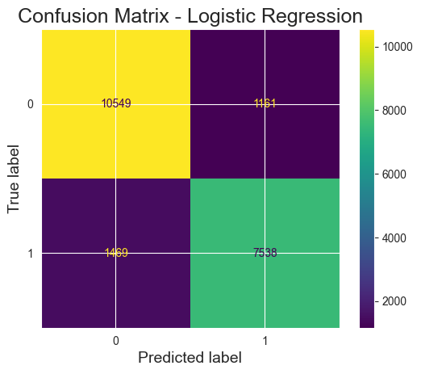

```
⏱️ Time taken: 1.38 seconds
------------------------------------------------------------

📌 Decision Tree
✅ Cross-validation scores: [0.94297955 0.94503107 0.94720328 0.94581548 0.94327782]
✅ Mean CV score: 0.9449
🎯 Accuracy on Test Set: 0.9453
📋 Classification Report:
              precision    recall  f1-score   support

           0       0.95      0.95      0.95     11710
           1       0.93      0.94      0.94      9007

    accuracy                           0.95     20717
   macro avg       0.94      0.94      0.94     20717
weighted avg       0.95      0.95      0.95     20717
```

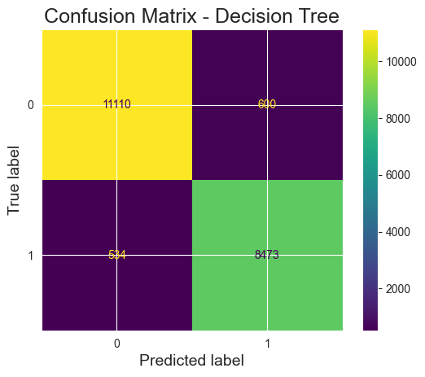

```
⏱️ Time taken: 3.66 seconds
------------------------------------------------------------

📌 Random Forest
✅ Cross-validation scores: [0.9595728  0.95909009 0.96295179 0.9620467  0.96276853]
✅ Mean CV score: 0.9613
🎯 Accuracy on Test Set: 0.9631
📋 Classification Report:
              precision    recall  f1-score   support

           0       0.96      0.98      0.97     11710
           1       0.97      0.94      0.96      9007

    accuracy                           0.96     20717
   macro avg       0.96      0.96      0.96     20717
weighted avg       0.96      0.96      0.96     20717
```

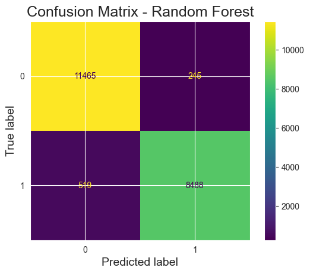

```
⏱️ Time taken: 64.67 seconds
------------------------------------------------------------

📌 Gradient Boosting
✅ Cross-validation scores: [0.93833343 0.94014361 0.94285887 0.94189344 0.94273473]
✅ Mean CV score: 0.9412
🎯 Accuracy on Test Set: 0.9426
📋 Classification Report:
              precision    recall  f1-score   support

           0       0.94      0.96      0.95     11710
           1       0.94      0.92      0.93      9007

    accuracy                           0.94     20717
   macro avg       0.94      0.94      0.94     20717
weighted avg       0.94      0.94      0.94     20717
```

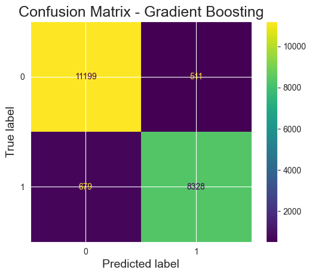

```
⏱️ Time taken: 87.35 seconds
------------------------------------------------------------

📌 KNN
✅ Cross-validation scores: [0.92288662 0.92674833 0.93036867 0.92523985 0.92861453]
✅ Mean CV score: 0.9268
🎯 Accuracy on Test Set: 0.9279
📋 Classification Report:
              precision    recall  f1-score   support

           0       0.91      0.96      0.94     11710
           1       0.95      0.88      0.91      9007

    accuracy                           0.93     20717
   macro avg       0.93      0.92      0.93     20717
weighted avg       0.93      0.93      0.93     20717
```

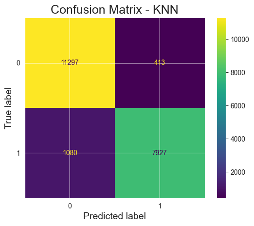

```
⏱️ Time taken: 16.49 seconds
------------------------------------------------------------
```

```python
for name, model in models.items():
    print(f"\n📌 {name}")

    # Convert y_train and y_test to 1D arrays to avoid warnings
    y_train = y_train.ravel()  # Flatten y_train
    y_test = y_test.ravel()    # Flatten y_test

    # Start measuring time
    start_time = time.time()

    # Perform 5-fold Cross-Validation on training data
    cv_scores = cross_val_score(model, X_train, y_train, cv=5)
    mean_cv = cv_scores.mean()
    print(f"✅ Cross-validation scores: {cv_scores}")
    print(f"✅ Mean CV score: {mean_cv:.4f}")

    # Fit the model on the full training set
    model.fit(X_train, y_train)

    # Predict on the test set
    y_pred = model.predict(X_test)

    # Print Accuracy and Classification Report
    acc = accuracy_score(y_test, y_pred)
    print(f"🎯 Accuracy on Test Set: {acc:.4f}")
    print("📋 Classification Report:")
    print(classification_report(y_test, y_pred))

    # Display Confusion Matrix
    cm = confusion_matrix(y_test, y_pred)
    disp = ConfusionMatrixDisplay(confusion_matrix=cm)
    disp.plot()
    plt.title(f'Confusion Matrix - {name}')
    plt.show()

    # Calculate time taken
    end_time = time.time()
    duration = end_time - start_time
    print(f"⏱️ Time taken: {duration:.2f} seconds")

    print("-" * 60)

    # Track best model based on highest mean CV score
    if mean_cv > best_score:
        best_score = mean_cv
        best_model = model
        best_model_name = name
```

# 📝 the Best Model Summary

```python
#  Print the Best Model Summary
print("\n Best Model Selected:")
print(f" Model: {best_model_name}")
print(f" Best Mean CV Score: {best_score:.4f}")
```

```
 Best Model Selected:
 Model: Random Forest
 Best Mean CV Score: 0.9613
```

# 🔍 Hyperparameter Tuning for Random Forest Model

```python
#  Define the hyperparameter grid to search
param_grid = {
    'n_estimators': [100, 200, 300],        # Number of trees in the forest
    'max_depth': [None, 10, 20],            # Maximum depth of the trees
    'min_samples_split': [2, 5],            # Minimum number of samples required to split a node
    'max_features': ['sqrt', 'log2']        # Number of features to consider when looking for the best split
}

# Create a base Random Forest model
rf_base = RandomForestClassifier(random_state=42)

# Perform Grid Search with 5-fold Cross-Validation
grid_search = GridSearchCV(
    estimator=rf_base,
    param_grid=param_grid,
    scoring='accuracy',
    cv=5,
    n_jobs=-1,            # Use all available CPU cores
    verbose=1             # Show progress
)

# Fit Grid Search on the training data
grid_search.fit(X_train, y_train)

# ✅ Display the best parameters and best score
print("\n✅✅ Best Parameters Found:")
print(grid_search.best_params_)
print(f"📈 Best Cross-Validation Accuracy: {grid_search.best_score_:.4f}")

'''
✅✅ Best Parameters Found:
{'max_depth': None, 'max_features': 'sqrt', 'min_samples_split': 2, 'n_estimators': 300}
📈 Best Cross-Validation Accuracy: 0.9619
'''
```

```
Fitting 5 folds for each of 36 candidates, totalling 180 fits

✅✅ Best Parameters Found:
{'max_depth': None, 'max_features': 'sqrt', 'min_samples_split': 2, 'n_estimators': 300}
📈 Best Cross-Validation Accuracy: 0.9619
```

# 📝 Evaluate the Tuned Model on Test Set

```
🎯 Accuracy on Test Set after Tuning: 0.9632
📋 Classification Report:
              precision    recall  f1-score   support

           0       0.96      0.98      0.97     11710
           1       0.97      0.94      0.96      9007

    accuracy                           0.96     20717
   macro avg       0.96      0.96      0.96     20717
weighted avg       0.96      0.96      0.96     20717
```

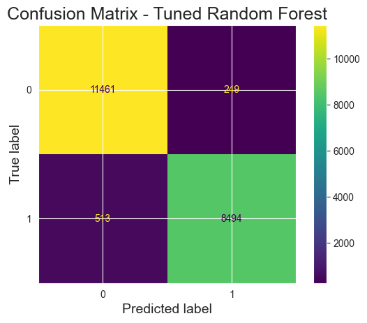

```python
# Get the best estimator after tuning
best_rf_model = grid_search.best_estimator_

# Predict on test data
y_pred_tuned = best_rf_model.predict(X_test)

# Evaluate performance
print(f"\n🎯 Accuracy on Test Set after Tuning: {accuracy_score(y_test, y_pred_tuned):.4f}")
print("📋 Classification Report:")
print(classification_report(y_test, y_pred_tuned))

# Display Confusion Matrix
cm = confusion_matrix(y_test, y_pred_tuned)
disp = ConfusionMatrixDisplay(confusion_matrix=cm)
disp.plot()
plt.title('Confusion Matrix - Tuned Random Forest')
plt.show()
```

# 💾✅ Saving the Trained Model with Joblib for Deployment

```python
# Save the trained model
joblib.dump(best_model, 'random_forest_model.pkl')
```

```
['random_forest_model.pkl']
```